# matplotlib.dates

[figure not shown]

Matplotlib provides sophisticated date plotting capabilities, standing on the shoulders of python [`datetime`](https://docs.python.org/3/library/datetime.html#module-datetime) and the add-on module [dateutil](https://dateutil.readthedocs.io).

By default, Matplotlib uses the units machinery described in `units` to convert [`datetime.datetime`](https://docs.python.org/3/library/datetime.html#datetime.datetime), and [`numpy.datetime64`](https://numpy.org/doc/stable/reference/arrays.scalars.html#numpy.datetime64) objects when plotted on an x- or y-axis. The user does not need to do anything for dates to be formatted, but dates often have strict formatting needs, so this module provides many tick locators and formatters. A basic example using [`numpy.datetime64`](https://numpy.org/doc/stable/reference/arrays.scalars.html#numpy.datetime64) is:

```
import numpy as np

times = np.arange(np.datetime64('2001-01-02'),
                  np.datetime64('2002-02-03'), np.timedelta64(75, 'm'))
y = np.random.randn(len(times))

fig, ax = plt.subplots()
ax.plot(times, y)
```

See also

- [Date tick labels](https://matplotlib.org/stable/gallery/text_labels_and_annotations/date.html)
- [Format date ticks using ConciseDateFormatter](https://matplotlib.org/stable/gallery/ticks/date_concise_formatter.html)
- [Date Demo Convert](https://matplotlib.org/stable/gallery/ticks/date_demo_convert.html)

## Matplotlib date format

Matplotlib represents dates using floating point numbers specifying the number of days since a default epoch of 1970-01-01 UTC; for example, 1970-01-01, 06:00 is the floating point number 0.25. The formatters and locators require the use of [`datetime.datetime`](https://docs.python.org/3/library/datetime.html#datetime.datetime) objects, so only dates between year 0001 and 9999 can be represented. Microsecond precision is achievable for (approximately) 70 years on either side of the epoch, and 20 microseconds for the rest of the allowable range of dates (year 0001 to 9999). The epoch can be changed at import time via `dates.set_epoch` or `rcParams["date.epoch"]` (default: `'1970-01-01T00:00:00'`) to other dates if necessary; see [Date precision and epochs](https://matplotlib.org/stable/gallery/ticks/date_precision_and_epochs.html) for a discussion.

Note

Before Matplotlib 3.3, the epoch was 0000-12-31 which lost modern microsecond precision and also made the default axis limit of 0 an invalid datetime. In 3.3 the epoch was changed as above. To convert old ordinal floats to the new epoch, users can do:

```
new_ordinal = old_ordinal + mdates.date2num(np.datetime64('0000-12-31'))
```

There are a number of helper functions to convert between [`datetime`](https://docs.python.org/3/library/datetime.html#module-datetime) objects and Matplotlib dates:

| `datestr2num` | Convert a date string to a datenum using [`dateutil.parser.parse`](https://dateutil.readthedocs.io/en/stable/parser.html#dateutil.parser.parse). |
| --- | --- |
| `date2num` | Convert datetime objects to Matplotlib dates. |
| `num2date` | Convert Matplotlib dates to [`datetime`](https://docs.python.org/3/library/datetime.html#datetime.datetime) objects. |
| `num2timedelta` | Convert number of days to a [`timedelta`](https://docs.python.org/3/library/datetime.html#datetime.timedelta) object. |
| `drange` | Return a sequence of equally spaced Matplotlib dates. |
| `set_epoch` | Set the epoch (origin for dates) for datetime calculations. |
| `get_epoch` | Get the epoch used by `dates`. |

Note

Like Python's [`datetime.datetime`](https://docs.python.org/3/library/datetime.html#datetime.datetime), Matplotlib uses the Gregorian calendar for all conversions between dates and floating point numbers. This practice is not universal, and calendar differences can cause confusing differences between what Python and Matplotlib give as the number of days since 0001-01-01 and what other software and databases yield. For example, the US Naval Observatory uses a calendar that switches from Julian to Gregorian in October, 1582. Hence, using their calculator, the number of days between 0001-01-01 and 2006-04-01 is 732403, whereas using the Gregorian calendar via the datetime module we find:

```
In [1]: date(2006, 4, 1).toordinal() - date(1, 1, 1).toordinal()
Out[1]: 732401
```

All the Matplotlib date converters, locators and formatters are timezone aware. If no explicit timezone is provided, `rcParams["timezone"]` (default: `'UTC'`) is assumed, provided as a string. If you want to use a different timezone, pass the *tz* keyword argument of `num2date` to any date tick locators or formatters you create. This can be either a [`datetime.tzinfo`](https://docs.python.org/3/library/datetime.html#datetime.tzinfo) instance or a string with the timezone name that can be parsed by [`gettz`](https://dateutil.readthedocs.io/en/stable/tz.html#dateutil.tz.gettz).

A wide range of specific and general purpose date tick locators and formatters are provided in this module. See `matplotlib.ticker` for general information on tick locators and formatters. These are described below.

The [dateutil](https://dateutil.readthedocs.io) module provides additional code to handle date ticking, making it easy to place ticks on any kinds of dates. See examples below.

## Date tick locators

Most of the date tick locators can locate single or multiple ticks. For example:

```
# import constants for the days of the week
from matplotlib.dates import MO, TU, WE, TH, FR, SA, SU

# tick on Mondays every week
loc = WeekdayLocator(byweekday=MO, tz=tz)

# tick on Mondays and Saturdays
loc = WeekdayLocator(byweekday=(MO, SA))
```

In addition, most of the constructors take an interval argument:

```
# tick on Mondays every second week
loc = WeekdayLocator(byweekday=MO, interval=2)
```

The rrule locator allows completely general date ticking:

```
# tick every 5th easter
rule = rrulewrapper(YEARLY, byeaster=1, interval=5)
loc = RRuleLocator(rule)
```

The available date tick locators are:

- `MicrosecondLocator`: Locate microseconds.
- `SecondLocator`: Locate seconds.
- `MinuteLocator`: Locate minutes.
- `HourLocator`: Locate hours.
- `DayLocator`: Locate specified days of the month.
- `WeekdayLocator`: Locate days of the week, e.g., MO, TU.
- `MonthLocator`: Locate months, e.g., 7 for July.
- `YearLocator`: Locate years that are multiples of base.
- `RRuleLocator`: Locate using a `rrulewrapper`. `rrulewrapper` is a simple wrapper around [dateutil](https://dateutil.readthedocs.io)'s [`dateutil.rrule`](https://dateutil.readthedocs.io/en/stable/rrule.html#module-dateutil.rrule) which allow almost arbitrary date tick specifications. See [rrule example](https://matplotlib.org/stable/gallery/ticks/date_demo_rrule.html).
- `AutoDateLocator`: On autoscale, this class picks the best `DateLocator` (e.g., `RRuleLocator`) to set the view limits and the tick locations. If called with `interval_multiples=True` it will make ticks line up with sensible multiples of the tick intervals. For example, if the interval is 4 hours, it will pick hours 0, 4, 8, etc. as ticks. This behaviour is not guaranteed by default.

## Date formatters

The available date formatters are:

- `AutoDateFormatter`: attempts to figure out the best format to use. This is most useful when used with the `AutoDateLocator`.
- `ConciseDateFormatter`: also attempts to figure out the best format to use, and to make the format as compact as possible while still having complete date information. This is most useful when used with the `AutoDateLocator`.
- `DateFormatter`: use [`strftime`](https://docs.python.org/3/library/datetime.html#datetime.datetime.strftime) format strings.

**class*matplotlib.dates.AutoDateFormatter(*locator*, *tz=None*, *defaultfmt='%Y-%m-%d'*, *, *usetex=None*)[[source]](https://github.com/matplotlib/matplotlib/blob/v3.10.8/lib/matplotlib/dates.py#L822-L938)**

Bases: `Formatter`

A `Formatter` which attempts to figure out the best format to use. This is most useful when used with the `AutoDateLocator`.

`AutoDateFormatter` has a `.scale` dictionary that maps tick scales (the interval in days between one major tick) to format strings; this dictionary defaults to

```
self.scaled = {
    DAYS_PER_YEAR: rcParams['date.autoformatter.year'],
    DAYS_PER_MONTH: rcParams['date.autoformatter.month'],
    1: rcParams['date.autoformatter.day'],
    1 / HOURS_PER_DAY: rcParams['date.autoformatter.hour'],
    1 / MINUTES_PER_DAY: rcParams['date.autoformatter.minute'],
    1 / SEC_PER_DAY: rcParams['date.autoformatter.second'],
    1 / MUSECONDS_PER_DAY: rcParams['date.autoformatter.microsecond'],
}
```

The formatter uses the format string corresponding to the lowest key in the dictionary that is greater or equal to the current scale. Dictionary entries can be customized:

```
locator = AutoDateLocator()
formatter = AutoDateFormatter(locator)
formatter.scaled[1/(24*60)] = '%M:%S' # only show min and sec
```

Custom callables can also be used instead of format strings. The following example shows how to use a custom format function to strip trailing zeros from decimal seconds and adds the date to the first ticklabel:

```
def my_format_function(x, pos=None):
    x = matplotlib.dates.num2date(x)
    if pos == 0:
        fmt = '%D %H:%M:%S.%f'
    else:
        fmt = '%H:%M:%S.%f'
    label = x.strftime(fmt)
    label = label.rstrip("0")
    label = label.rstrip(".")
    return label

formatter.scaled[1/(24*60)] = my_format_function
```

Autoformat the date labels.

**Parameters:**

**locator**`ticker.Locator`**

Locator that this axis is using.

**tz**str or [`tzinfo`](https://docs.python.org/3/library/datetime.html#datetime.tzinfo), default: `rcParams["timezone"]` (default: `'UTC'`)**

Ticks timezone. If a string, *tz* is passed to [`dateutil.tz`](https://dateutil.readthedocs.io/en/stable/tz.html#module-dateutil.tz).

**defaultfmt**str**

The default format to use if none of the values in `self.scaled` are greater than the unit returned by `locator._get_unit()`.

**usetex**bool, default: `rcParams["text.usetex"]` (default: `False`)**

To enable/disable the use of TeX's math mode for rendering the results of the formatter. If any entries in `self.scaled` are set as functions, then it is up to the customized function to enable or disable TeX's math mode itself.

**class*matplotlib.dates.AutoDateLocator(*tz=None*, *minticks=5*, *maxticks=None*, *interval_multiples=True*)[[source]](https://github.com/matplotlib/matplotlib/blob/v3.10.8/lib/matplotlib/dates.py#L1214-L1444)**

Bases: `DateLocator`

On autoscale, this class picks the best `DateLocator` to set the view limits and the tick locations.

**Attributes:**

**intervald**dict**

Mapping of tick frequencies to multiples allowed for that ticking. The default is

```
self.intervald = {
    YEARLY  : [1, 2, 4, 5, 10, 20, 40, 50, 100, 200, 400, 500,
               1000, 2000, 4000, 5000, 10000],
    MONTHLY : [1, 2, 3, 4, 6],
    DAILY   : [1, 2, 3, 7, 14, 21],
    HOURLY  : [1, 2, 3, 4, 6, 12],
    MINUTELY: [1, 5, 10, 15, 30],
    SECONDLY: [1, 5, 10, 15, 30],
    MICROSECONDLY: [1, 2, 5, 10, 20, 50, 100, 200, 500,
                    1000, 2000, 5000, 10000, 20000, 50000,
                    100000, 200000, 500000, 1000000],
}
```

where the keys are defined in [`dateutil.rrule`](https://dateutil.readthedocs.io/en/stable/rrule.html#module-dateutil.rrule).

The interval is used to specify multiples that are appropriate for the frequency of ticking. For instance, every 7 days is sensible for daily ticks, but for minutes/seconds, 15 or 30 make sense.

When customizing, you should only modify the values for the existing keys. You should not add or delete entries.

Example for forcing ticks every 3 hours:

```
locator = AutoDateLocator()
locator.intervald[HOURLY] = [3]  # only show every 3 hours
```

**Parameters:**

**tz**str or [`tzinfo`](https://docs.python.org/3/library/datetime.html#datetime.tzinfo), default: `rcParams["timezone"]` (default: `'UTC'`)**

Ticks timezone. If a string, *tz* is passed to [`dateutil.tz`](https://dateutil.readthedocs.io/en/stable/tz.html#module-dateutil.tz).

**minticks**int**

The minimum number of ticks desired; controls whether ticks occur yearly, monthly, etc.

**maxticks**int**

The maximum number of ticks desired; controls the interval between ticks (ticking every other, every 3, etc.). For fine-grained control, this can be a dictionary mapping individual rrule frequency constants (YEARLY, MONTHLY, etc.) to their own maximum number of ticks. This can be used to keep the number of ticks appropriate to the format chosen in `AutoDateFormatter`. Any frequency not specified in this dictionary is given a default value.

**interval_multiples**bool, default: True**

Whether ticks should be chosen to be multiple of the interval, locking them to 'nicer' locations. For example, this will force the ticks to be at hours 0, 6, 12, 18 when hourly ticking is done at 6 hour intervals.

**get_locator(*dmin*, *dmax*)[[source]](https://github.com/matplotlib/matplotlib/blob/v3.10.8/lib/matplotlib/dates.py#L1346-L1444)**

Pick the best locator based on a distance.

**nonsingular(*vmin*, *vmax*)[[source]](https://github.com/matplotlib/matplotlib/blob/v3.10.8/lib/matplotlib/dates.py#L1326-L1338)**

Given the proposed upper and lower extent, adjust the range if it is too close to being singular (i.e. a range of ~0).

**tick_values(*vmin*, *vmax*)[[source]](https://github.com/matplotlib/matplotlib/blob/v3.10.8/lib/matplotlib/dates.py#L1323-L1324)**

Return the values of the located ticks given **vmin** and **vmax**.

Note

To get tick locations with the vmin and vmax values defined automatically for the associated `axis` simply call the Locator instance:

```
>>> print(type(loc))
<type 'Locator'>
>>> print(loc())
[1, 2, 3, 4]
```

**class*matplotlib.dates.ConciseDateConverter(*formats=None*, *zero_formats=None*, *offset_formats=None*, *show_offset=True*, *, *interval_multiples=True*)[[source]](https://github.com/matplotlib/matplotlib/blob/v3.10.8/lib/matplotlib/dates.py#L1785-L1809)**

Bases: `DateConverter`

**axisinfo(*unit*, *axis*)[[source]](https://github.com/matplotlib/matplotlib/blob/v3.10.8/lib/matplotlib/dates.py#L1797-L1809)**

Return the `AxisInfo` for *unit*.

*unit* is a [`tzinfo`](https://docs.python.org/3/library/datetime.html#datetime.tzinfo) instance or None. The *axis* argument is required but not used.

**class*matplotlib.dates.ConciseDateFormatter(*locator*, *tz=None*, *formats=None*, *offset_formats=None*, *zero_formats=None*, *show_offset=True*, *, *usetex=None*)[[source]](https://github.com/matplotlib/matplotlib/blob/v3.10.8/lib/matplotlib/dates.py#L597-L819)**

Bases: `Formatter`

A `Formatter` which attempts to figure out the best format to use for the date, and to make it as compact as possible, but still be complete. This is most useful when used with the `AutoDateLocator`:

```
>>> locator = AutoDateLocator()
>>> formatter = ConciseDateFormatter(locator)
```

**Parameters:**

**locator**`ticker.Locator`**

Locator that this axis is using.

**tz**str or [`tzinfo`](https://docs.python.org/3/library/datetime.html#datetime.tzinfo), default: `rcParams["timezone"]` (default: `'UTC'`)**

Ticks timezone, passed to `dates.num2date`.

**formats**list of 6 strings, optional**

Format strings for 6 levels of tick labelling: mostly years, months, days, hours, minutes, and seconds. Strings use the same format codes as [`strftime`](https://docs.python.org/3/library/datetime.html#datetime.datetime.strftime). Default is `['%Y', '%b', '%d', '%H:%M', '%H:%M', '%S.%f']`

**zero_formats**list of 6 strings, optional**

Format strings for tick labels that are "zeros" for a given tick level. For instance, if most ticks are months, ticks around 1 Jan 2005 will be labeled "Dec", "2005", "Feb". The default is `['', '%Y', '%b', '%b-%d', '%H:%M', '%H:%M']`

**offset_formats**list of 6 strings, optional**

Format strings for the 6 levels that is applied to the "offset" string found on the right side of an x-axis, or top of a y-axis. Combined with the tick labels this should completely specify the date. The default is:

```
['', '%Y', '%Y-%b', '%Y-%b-%d', '%Y-%b-%d', '%Y-%b-%d %H:%M']
```

**show_offset**bool, default: True**

Whether to show the offset or not.

**usetex**bool, default: `rcParams["text.usetex"]` (default: `False`)**

To enable/disable the use of TeX's math mode for rendering the results of the formatter.

#### Examples

See [Format date ticks using ConciseDateFormatter](https://matplotlib.org/stable/gallery/ticks/date_concise_formatter.html)

([`Source code`](https://matplotlib.org/stable/_downloads/d35cfd2538cb0601780e50ada2a98dba/dates_api-1.py), [`2x.png`](https://matplotlib.org/stable/_downloads/c41e985a7a2bb0e0d3c34d89a8267079/dates_api-1.2x.png), [`png`](https://matplotlib.org/stable/_downloads/17e5a51e538bb9397dea9277dd9855ec/dates_api-1.png))

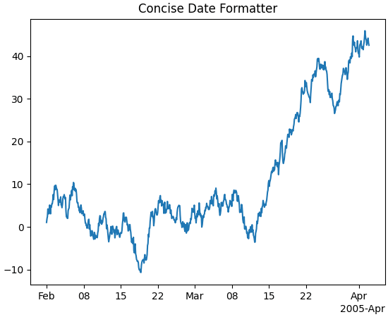

Autoformat the date labels. The default format is used to form an initial string, and then redundant elements are removed.

**format_data_short(*value*)[[source]](https://github.com/matplotlib/matplotlib/blob/v3.10.8/lib/matplotlib/dates.py#L818-L819)**

Return a short string version of the tick value.

Defaults to the position-independent long value.

**format_ticks(*values*)[[source]](https://github.com/matplotlib/matplotlib/blob/v3.10.8/lib/matplotlib/dates.py#L731-L813)**

Return the tick labels for all the ticks at once.

**get_offset()[[source]](https://github.com/matplotlib/matplotlib/blob/v3.10.8/lib/matplotlib/dates.py#L815-L816)**

**class*matplotlib.dates.DateConverter(*, *interval_multiples=True*)[[source]](https://github.com/matplotlib/matplotlib/blob/v3.10.8/lib/matplotlib/dates.py#L1724-L1782)**

Bases: `ConversionInterface`

Converter for [`datetime.date`](https://docs.python.org/3/library/datetime.html#datetime.date) and [`datetime.datetime`](https://docs.python.org/3/library/datetime.html#datetime.datetime) data, or for date/time data represented as it would be converted by `date2num`.

The 'unit' tag for such data is None or a [`tzinfo`](https://docs.python.org/3/library/datetime.html#datetime.tzinfo) instance.

**axisinfo(*unit*, *axis*)[[source]](https://github.com/matplotlib/matplotlib/blob/v3.10.8/lib/matplotlib/dates.py#L1736-L1752)**

Return the `AxisInfo` for *unit*.

*unit* is a [`tzinfo`](https://docs.python.org/3/library/datetime.html#datetime.tzinfo) instance or None. The *axis* argument is required but not used.

**static*convert(*value*, *unit*, *axis*)[[source]](https://github.com/matplotlib/matplotlib/blob/v3.10.8/lib/matplotlib/dates.py#L1754-L1762)**

If *value* is not already a number or sequence of numbers, convert it with `date2num`.

The *unit* and *axis* arguments are not used.

**static*default_units(*x*, *axis*)[[source]](https://github.com/matplotlib/matplotlib/blob/v3.10.8/lib/matplotlib/dates.py#L1764-L1782)**

Return the [`tzinfo`](https://docs.python.org/3/library/datetime.html#datetime.tzinfo) instance of *x* or of its first element, or None

**class*matplotlib.dates.DateFormatter(*fmt*, *tz=None*, *, *usetex=None*)[[source]](https://github.com/matplotlib/matplotlib/blob/v3.10.8/lib/matplotlib/dates.py#L567-L594)**

Bases: `Formatter`

Format a tick (in days since the epoch) with a [`strftime`](https://docs.python.org/3/library/datetime.html#datetime.datetime.strftime) format string.

**Parameters:**

**fmt**str**

[`strftime`](https://docs.python.org/3/library/datetime.html#datetime.datetime.strftime) format string

**tz**str or [`tzinfo`](https://docs.python.org/3/library/datetime.html#datetime.tzinfo), default: `rcParams["timezone"]` (default: `'UTC'`)**

Ticks timezone. If a string, *tz* is passed to [`dateutil.tz`](https://dateutil.readthedocs.io/en/stable/tz.html#module-dateutil.tz).

**usetex**bool, default: `rcParams["text.usetex"]` (default: `False`)**

To enable/disable the use of TeX's math mode for rendering the results of the formatter.

**set_tzinfo(*tz*)[[source]](https://github.com/matplotlib/matplotlib/blob/v3.10.8/lib/matplotlib/dates.py#L593-L594)**

**class*matplotlib.dates.DateLocator(*tz=None*)[[source]](https://github.com/matplotlib/matplotlib/blob/v3.10.8/lib/matplotlib/dates.py#L1062-L1135)**

Bases: `Locator`

Determines the tick locations when plotting dates.

This class is subclassed by other Locators and is not meant to be used on its own.

**Parameters:**

**tz**str or [`tzinfo`](https://docs.python.org/3/library/datetime.html#datetime.tzinfo), default: `rcParams["timezone"]` (default: `'UTC'`)**

Ticks timezone. If a string, *tz* is passed to [`dateutil.tz`](https://dateutil.readthedocs.io/en/stable/tz.html#module-dateutil.tz).

**datalim_to_dt()[[source]](https://github.com/matplotlib/matplotlib/blob/v3.10.8/lib/matplotlib/dates.py#L1091-L1097)**

Convert axis data interval to datetime objects.

**hms0d*={'byhour': 0, 'byminute': 0, 'bysecond': 0}**

**nonsingular(*vmin*, *vmax*)[[source]](https://github.com/matplotlib/matplotlib/blob/v3.10.8/lib/matplotlib/dates.py#L1119-L1135)**

Given the proposed upper and lower extent, adjust the range if it is too close to being singular (i.e. a range of ~0).

**set_tzinfo(*tz*)[[source]](https://github.com/matplotlib/matplotlib/blob/v3.10.8/lib/matplotlib/dates.py#L1080-L1089)**

Set timezone info.

**Parameters:**

**tz**str or [`tzinfo`](https://docs.python.org/3/library/datetime.html#datetime.tzinfo), default: `rcParams["timezone"]` (default: `'UTC'`)**

Ticks timezone. If a string, *tz* is passed to [`dateutil.tz`](https://dateutil.readthedocs.io/en/stable/tz.html#module-dateutil.tz).

**viewlim_to_dt()[[source]](https://github.com/matplotlib/matplotlib/blob/v3.10.8/lib/matplotlib/dates.py#L1099-L1104)**

Convert the view interval to datetime objects.

**class*matplotlib.dates.DayLocator(*bymonthday=None*, *interval=1*, *tz=None*)[[source]](https://github.com/matplotlib/matplotlib/blob/v3.10.8/lib/matplotlib/dates.py#L1551-L1576)**

Bases: `RRuleLocator`

Make ticks on occurrences of each day of the month. For example, 1, 15, 30.

**Parameters:**

**bymonthday**int or list of int, default: all days**

Ticks will be placed on every day in *bymonthday*. Default is `bymonthday=range(1, 32)`, i.e., every day of the month.

**interval**int, default: 1**

The interval between each iteration. For example, if `interval=2`, mark every second occurrence.

**tz**str or [`tzinfo`](https://docs.python.org/3/library/datetime.html#datetime.tzinfo), default: `rcParams["timezone"]` (default: `'UTC'`)**

Ticks timezone. If a string, *tz* is passed to [`dateutil.tz`](https://dateutil.readthedocs.io/en/stable/tz.html#module-dateutil.tz).

**class*matplotlib.dates.HourLocator(*byhour=None*, *interval=1*, *tz=None*)[[source]](https://github.com/matplotlib/matplotlib/blob/v3.10.8/lib/matplotlib/dates.py#L1579-L1601)**

Bases: `RRuleLocator`

Make ticks on occurrences of each hour.

**Parameters:**

**byhour**int or list of int, default: all hours**

Ticks will be placed on every hour in *byhour*. Default is `byhour=range(24)`, i.e., every hour.

**interval**int, default: 1**

The interval between each iteration. For example, if `interval=2`, mark every second occurrence.

**tz**str or [`tzinfo`](https://docs.python.org/3/library/datetime.html#datetime.tzinfo), default: `rcParams["timezone"]` (default: `'UTC'`)**

Ticks timezone. If a string, *tz* is passed to [`dateutil.tz`](https://dateutil.readthedocs.io/en/stable/tz.html#module-dateutil.tz).

**class*matplotlib.dates.MicrosecondLocator(*interval=1*, *tz=None*)[[source]](https://github.com/matplotlib/matplotlib/blob/v3.10.8/lib/matplotlib/dates.py#L1653-L1721)**

Bases: `DateLocator`

Make ticks on regular intervals of one or more microsecond(s).

Note

By default, Matplotlib uses a floating point representation of time in days since the epoch, so plotting data with microsecond time resolution does not work well for dates that are far (about 70 years) from the epoch (check with `get_epoch`).

If you want sub-microsecond resolution time plots, it is strongly recommended to use floating point seconds, not datetime-like time representation.

If you really must use datetime.datetime() or similar and still need microsecond precision, change the time origin via `dates.set_epoch` to something closer to the dates being plotted. See [Date precision and epochs](https://matplotlib.org/stable/gallery/ticks/date_precision_and_epochs.html).

**Parameters:**

**interval**int, default: 1**

The interval between each iteration. For example, if `interval=2`, mark every second occurrence.

**tz**str or [`tzinfo`](https://docs.python.org/3/library/datetime.html#datetime.tzinfo), default: `rcParams["timezone"]` (default: `'UTC'`)**

Ticks timezone. If a string, *tz* is passed to [`dateutil.tz`](https://dateutil.readthedocs.io/en/stable/tz.html#module-dateutil.tz).

**set_axis(*axis*)[[source]](https://github.com/matplotlib/matplotlib/blob/v3.10.8/lib/matplotlib/dates.py#L1689-L1691)**

**tick_values(*vmin*, *vmax*)[[source]](https://github.com/matplotlib/matplotlib/blob/v3.10.8/lib/matplotlib/dates.py#L1702-L1713)**

Return the values of the located ticks given **vmin** and **vmax**.

Note

To get tick locations with the vmin and vmax values defined automatically for the associated `axis` simply call the Locator instance:

```
>>> print(type(loc))
<type 'Locator'>
>>> print(loc())
[1, 2, 3, 4]
```

**class*matplotlib.dates.MinuteLocator(*byminute=None*, *interval=1*, *tz=None*)[[source]](https://github.com/matplotlib/matplotlib/blob/v3.10.8/lib/matplotlib/dates.py#L1604-L1626)**

Bases: `RRuleLocator`

Make ticks on occurrences of each minute.

**Parameters:**

**byminute**int or list of int, default: all minutes**

Ticks will be placed on every minute in *byminute*. Default is `byminute=range(60)`, i.e., every minute.

**interval**int, default: 1**

The interval between each iteration. For example, if `interval=2`, mark every second occurrence.

**tz**str or [`tzinfo`](https://docs.python.org/3/library/datetime.html#datetime.tzinfo), default: `rcParams["timezone"]` (default: `'UTC'`)**

Ticks timezone. If a string, *tz* is passed to [`dateutil.tz`](https://dateutil.readthedocs.io/en/stable/tz.html#module-dateutil.tz).

**class*matplotlib.dates.MonthLocator(*bymonth=None*, *bymonthday=1*, *interval=1*, *tz=None*)[[source]](https://github.com/matplotlib/matplotlib/blob/v3.10.8/lib/matplotlib/dates.py#L1497-L1521)**

Bases: `RRuleLocator`

Make ticks on occurrences of each month, e.g., 1, 3, 12.

**Parameters:**

**bymonth**int or list of int, default: all months**

Ticks will be placed on every month in *bymonth*. Default is `range(1, 13)`, i.e. every month.

**bymonthday**int, default: 1**

The day on which to place the ticks.

**interval**int, default: 1**

The interval between each iteration. For example, if `interval=2`, mark every second occurrence.

**tz**str or [`tzinfo`](https://docs.python.org/3/library/datetime.html#datetime.tzinfo), default: `rcParams["timezone"]` (default: `'UTC'`)**

Ticks timezone. If a string, *tz* is passed to [`dateutil.tz`](https://dateutil.readthedocs.io/en/stable/tz.html#module-dateutil.tz).

**class*matplotlib.dates.RRuleLocator(*o*, *tz=None*)[[source]](https://github.com/matplotlib/matplotlib/blob/v3.10.8/lib/matplotlib/dates.py#L1138-L1211)**

Bases: `DateLocator`

**Parameters:**

**tz**str or [`tzinfo`](https://docs.python.org/3/library/datetime.html#datetime.tzinfo), default: `rcParams["timezone"]` (default: `'UTC'`)**

Ticks timezone. If a string, *tz* is passed to [`dateutil.tz`](https://dateutil.readthedocs.io/en/stable/tz.html#module-dateutil.tz).

**static*get_unit_generic(*freq*)[[source]](https://github.com/matplotlib/matplotlib/blob/v3.10.8/lib/matplotlib/dates.py#L1190-L1208)**

**tick_values(*vmin*, *vmax*)[[source]](https://github.com/matplotlib/matplotlib/blob/v3.10.8/lib/matplotlib/dates.py#L1154-L1159)**

Return the values of the located ticks given **vmin** and **vmax**.

Note

To get tick locations with the vmin and vmax values defined automatically for the associated `axis` simply call the Locator instance:

```
>>> print(type(loc))
<type 'Locator'>
>>> print(loc())
[1, 2, 3, 4]
```

**class*matplotlib.dates.SecondLocator(*bysecond=None*, *interval=1*, *tz=None*)[[source]](https://github.com/matplotlib/matplotlib/blob/v3.10.8/lib/matplotlib/dates.py#L1629-L1650)**

Bases: `RRuleLocator`

Make ticks on occurrences of each second.

**Parameters:**

**bysecond**int or list of int, default: all seconds**

Ticks will be placed on every second in *bysecond*. Default is `bysecond = range(60)`, i.e., every second.

**interval**int, default: 1**

The interval between each iteration. For example, if `interval=2`, mark every second occurrence.

**tz**str or [`tzinfo`](https://docs.python.org/3/library/datetime.html#datetime.tzinfo), default: `rcParams["timezone"]` (default: `'UTC'`)**

Ticks timezone. If a string, *tz* is passed to [`dateutil.tz`](https://dateutil.readthedocs.io/en/stable/tz.html#module-dateutil.tz).

**class*matplotlib.dates.WeekdayLocator(*byweekday=1*, *interval=1*, *tz=None*)[[source]](https://github.com/matplotlib/matplotlib/blob/v3.10.8/lib/matplotlib/dates.py#L1524-L1548)**

Bases: `RRuleLocator`

Make ticks on occurrences of each weekday.

**Parameters:**

**byweekday**int or list of int, default: all days**

Ticks will be placed on every weekday in *byweekday*. Default is every day.

Elements of *byweekday* must be one of MO, TU, WE, TH, FR, SA, SU, the constants from [`dateutil.rrule`](https://dateutil.readthedocs.io/en/stable/rrule.html#module-dateutil.rrule), which have been imported into the `matplotlib.dates` namespace.

**interval**int, default: 1**

The interval between each iteration. For example, if `interval=2`, mark every second occurrence.

**tz**str or [`tzinfo`](https://docs.python.org/3/library/datetime.html#datetime.tzinfo), default: `rcParams["timezone"]` (default: `'UTC'`)**

Ticks timezone. If a string, *tz* is passed to [`dateutil.tz`](https://dateutil.readthedocs.io/en/stable/tz.html#module-dateutil.tz).

**class*matplotlib.dates.YearLocator(*base=1*, *month=1*, *day=1*, *tz=None*)[[source]](https://github.com/matplotlib/matplotlib/blob/v3.10.8/lib/matplotlib/dates.py#L1447-L1494)**

Bases: `RRuleLocator`

Make ticks on a given day of each year that is a multiple of base.

Examples:

```
# Tick every year on Jan 1st
locator = YearLocator()

# Tick every 5 years on July 4th
locator = YearLocator(5, month=7, day=4)
```

**Parameters:**

**base**int, default: 1**

Mark ticks every *base* years.

**month**int, default: 1**

The month on which to place the ticks, starting from 1. Default is January.

**day**int, default: 1**

The day on which to place the ticks.

**tz**str or [`tzinfo`](https://docs.python.org/3/library/datetime.html#datetime.tzinfo), default: `rcParams["timezone"]` (default: `'UTC'`)**

Ticks timezone. If a string, *tz* is passed to [`dateutil.tz`](https://dateutil.readthedocs.io/en/stable/tz.html#module-dateutil.tz).

**matplotlib.dates.date2num(*d*)[[source]](https://github.com/matplotlib/matplotlib/blob/v3.10.8/lib/matplotlib/dates.py#L405-L454)**

Convert datetime objects to Matplotlib dates.

**Parameters:**

**d**[`datetime.datetime`](https://docs.python.org/3/library/datetime.html#datetime.datetime) or [`numpy.datetime64`](https://numpy.org/doc/stable/reference/arrays.scalars.html#numpy.datetime64) or sequences of these**

**Returns:**

**float or sequence of floats**

Number of days since the epoch. See `get_epoch` for the epoch, which can be changed by `rcParams["date.epoch"]` (default: `'1970-01-01T00:00:00'`) or `set_epoch`. If the epoch is "1970-01-01T00:00:00" (default) then noon Jan 1 1970 ("1970-01-01T12:00:00") returns 0.5.

#### Notes

The Gregorian calendar is assumed; this is not universal practice. For details see the module docstring.

**matplotlib.dates.datestr2num(*d*, *default=None*)[[source]](https://github.com/matplotlib/matplotlib/blob/v3.10.8/lib/matplotlib/dates.py#L379-L402)**

Convert a date string to a datenum using [`dateutil.parser.parse`](https://dateutil.readthedocs.io/en/stable/parser.html#dateutil.parser.parse).

**Parameters:**

**d**str or sequence of str**

The dates to convert.

**default**datetime.datetime, optional**

The default date to use when fields are missing in *d*.

**matplotlib.dates.drange(*dstart*, *dend*, *delta*)[[source]](https://github.com/matplotlib/matplotlib/blob/v3.10.8/lib/matplotlib/dates.py#L510-L548)**

Return a sequence of equally spaced Matplotlib dates.

The dates start at *dstart* and reach up to, but not including *dend*. They are spaced by *delta*.

**Parameters:**

**dstart, dend**[`datetime`](https://docs.python.org/3/library/datetime.html#datetime.datetime)**

The date limits.

**delta**[`datetime.timedelta`](https://docs.python.org/3/library/datetime.html#datetime.timedelta)**

Spacing of the dates.

**Returns:**

**[`numpy.array`](https://numpy.org/doc/stable/reference/generated/numpy.array.html#numpy.array)**

A list floats representing Matplotlib dates.

**matplotlib.dates.get_epoch()[[source]](https://github.com/matplotlib/matplotlib/blob/v3.10.8/lib/matplotlib/dates.py#L295-L307)**

Get the epoch used by `dates`.

**Returns:**

**epoch**str**

String for the epoch (parsable by [`numpy.datetime64`](https://numpy.org/doc/stable/reference/arrays.scalars.html#numpy.datetime64)).

**matplotlib.dates.num2date(*x*, *tz=None*)[[source]](https://github.com/matplotlib/matplotlib/blob/v3.10.8/lib/matplotlib/dates.py#L457-L484)**

Convert Matplotlib dates to [`datetime`](https://docs.python.org/3/library/datetime.html#datetime.datetime) objects.

**Parameters:**

**x**float or sequence of floats**

Number of days (fraction part represents hours, minutes, seconds) since the epoch. See `get_epoch` for the epoch, which can be changed by `rcParams["date.epoch"]` (default: `'1970-01-01T00:00:00'`) or `set_epoch`.

**tz**str or [`tzinfo`](https://docs.python.org/3/library/datetime.html#datetime.tzinfo), default: `rcParams["timezone"]` (default: `'UTC'`)**

Timezone of *x*. If a string, *tz* is passed to [`dateutil.tz`](https://dateutil.readthedocs.io/en/stable/tz.html#module-dateutil.tz).

**Returns:**

**[`datetime`](https://docs.python.org/3/library/datetime.html#datetime.datetime) or sequence of [`datetime`](https://docs.python.org/3/library/datetime.html#datetime.datetime)**

Dates are returned in timezone *tz*.

If *x* is a sequence, a sequence of [`datetime`](https://docs.python.org/3/library/datetime.html#datetime.datetime) objects will be returned.

#### Notes

The Gregorian calendar is assumed; this is not universal practice. For details, see the module docstring.

**matplotlib.dates.num2timedelta(*x*)[[source]](https://github.com/matplotlib/matplotlib/blob/v3.10.8/lib/matplotlib/dates.py#L491-L507)**

Convert number of days to a [`timedelta`](https://docs.python.org/3/library/datetime.html#datetime.timedelta) object.

If *x* is a sequence, a sequence of [`timedelta`](https://docs.python.org/3/library/datetime.html#datetime.timedelta) objects will be returned.

**Parameters:**

**x**float, sequence of floats**

Number of days. The fraction part represents hours, minutes, seconds.

**Returns:**

**[`datetime.timedelta`](https://docs.python.org/3/library/datetime.html#datetime.timedelta) or list[[`datetime.timedelta`](https://docs.python.org/3/library/datetime.html#datetime.timedelta)]**

**class*matplotlib.dates.relativedelta(*dt1=None*, *dt2=None*, *years=0*, *months=0*, *days=0*, *leapdays=0*, *weeks=0*, *hours=0*, *minutes=0*, *seconds=0*, *microseconds=0*, *year=None*, *month=None*, *day=None*, *weekday=None*, *yearday=None*, *nlyearday=None*, *hour=None*, *minute=None*, *second=None*, *microsecond=None*)**

Bases: [`object`](https://docs.python.org/3/library/functions.html#object)

The relativedelta type is designed to be applied to an existing datetime and can replace specific components of that datetime, or represents an interval of time.

It is based on the specification of the excellent work done by M.-A. Lemburg in his [mx.DateTime](https://www.egenix.com/products/python/mxBase/mxDateTime/) extension. However, notice that this type does *NOT* implement the same algorithm as his work. Do *NOT* expect it to behave like mx.DateTime's counterpart.

There are two different ways to build a relativedelta instance. The first one is passing it two date/datetime classes:

```
relativedelta(datetime1, datetime2)
```

The second one is passing it any number of the following keyword arguments:

```
relativedelta(arg1=x,arg2=y,arg3=z...)

year, month, day, hour, minute, second, microsecond:
    Absolute information (argument is singular); adding or subtracting a
    relativedelta with absolute information does not perform an arithmetic
    operation, but rather REPLACES the corresponding value in the
    original datetime with the value(s) in relativedelta.

years, months, weeks, days, hours, minutes, seconds, microseconds:
    Relative information, may be negative (argument is plural); adding
    or subtracting a relativedelta with relative information performs
    the corresponding arithmetic operation on the original datetime value
    with the information in the relativedelta.

weekday:
    One of the weekday instances (MO, TU, etc) available in the
    relativedelta module. These instances may receive a parameter N,
    specifying the Nth weekday, which could be positive or negative
    (like MO(+1) or MO(-2)). Not specifying it is the same as specifying
    +1. You can also use an integer, where 0=MO. This argument is always
    relative e.g. if the calculated date is already Monday, using MO(1)
    or MO(-1) won't change the day. To effectively make it absolute, use
    it in combination with the day argument (e.g. day=1, MO(1) for first
    Monday of the month).

leapdays:
    Will add given days to the date found, if year is a leap
    year, and the date found is post 28 of february.

yearday, nlyearday:
    Set the yearday or the non-leap year day (jump leap days).
    These are converted to day/month/leapdays information.
```

There are relative and absolute forms of the keyword arguments. The plural is relative, and the singular is absolute. For each argument in the order below, the absolute form is applied first (by setting each attribute to that value) and then the relative form (by adding the value to the attribute).

The order of attributes considered when this relativedelta is added to a datetime is:

1. Year
2. Month
3. Day
4. Hours
5. Minutes
6. Seconds
7. Microseconds

Finally, weekday is applied, using the rule described above.

For example

```
>>> from datetime import datetime
>>> from dateutil.relativedelta import relativedelta, MO
>>> dt = datetime(2018, 4, 9, 13, 37, 0)
>>> delta = relativedelta(hours=25, day=1, weekday=MO(1))
>>> dt + delta
datetime.datetime(2018, 4, 2, 14, 37)
```

First, the day is set to 1 (the first of the month), then 25 hours are added, to get to the 2nd day and 14th hour, finally the weekday is applied, but since the 2nd is already a Monday there is no effect.

**normalized()**

Return a version of this object represented entirely using integer values for the relative attributes.

```
>>> relativedelta(days=1.5, hours=2).normalized()
relativedelta(days=+1, hours=+14)
```

**Returns:**

Returns a `dateutil.relativedelta.relativedelta` object.

**property*weeks**

**class*matplotlib.dates.rrulewrapper(*freq*, *tzinfo=None*, **kwargs)[[source]](https://github.com/matplotlib/matplotlib/blob/v3.10.8/lib/matplotlib/dates.py#L941-L1059)**

Bases: [`object`](https://docs.python.org/3/library/functions.html#object)

A simple wrapper around a [`dateutil.rrule`](https://dateutil.readthedocs.io/en/stable/rrule.html#module-dateutil.rrule) allowing flexible date tick specifications.

**Parameters:**

**freq**{YEARLY, MONTHLY, WEEKLY, DAILY, HOURLY, MINUTELY, SECONDLY}**

Tick frequency. These constants are defined in [`dateutil.rrule`](https://dateutil.readthedocs.io/en/stable/rrule.html#module-dateutil.rrule), but they are accessible from `matplotlib.dates` as well.

**tzinfo**[`datetime.tzinfo`](https://docs.python.org/3/library/datetime.html#datetime.tzinfo), optional**

Time zone information. The default is None.

**kwargs**

Additional keyword arguments are passed to the [`dateutil.rrule`](https://dateutil.readthedocs.io/en/stable/rrule.html#module-dateutil.rrule).

**set(**kwargs)[[source]](https://github.com/matplotlib/matplotlib/blob/v3.10.8/lib/matplotlib/dates.py#L963-L967)**

Set parameters for an existing wrapper.

**matplotlib.dates.set_epoch(*epoch*)[[source]](https://github.com/matplotlib/matplotlib/blob/v3.10.8/lib/matplotlib/dates.py#L266-L292)**

Set the epoch (origin for dates) for datetime calculations.

The default epoch is `rcParams["date.epoch"]` (default: `'1970-01-01T00:00:00'`).

If microsecond accuracy is desired, the date being plotted needs to be within approximately 70 years of the epoch. Matplotlib internally represents dates as days since the epoch, so floating point dynamic range needs to be within a factor of 2^52.

`set_epoch` must be called before any dates are converted (i.e. near the import section) or a RuntimeError will be raised.

See also [Date precision and epochs](https://matplotlib.org/stable/gallery/ticks/date_precision_and_epochs.html).

**Parameters:**

**epoch**str**

valid UTC date parsable by [`numpy.datetime64`](https://numpy.org/doc/stable/reference/arrays.scalars.html#numpy.datetime64) (do not include timezone).

© 2012–2026 Matplotlib Development Team. All rights reserved.  
Licensed under the Matplotlib License Agreement.  
https://matplotlib.org/stable/api/dates_api.html